# RNA-seq_Pipeline_RMD

Hamish WIlliams

2023-01-23

This is my first iteration of a RMD document to compile my code for the main protocols for performing RNA-seq analyses and downstream analyses, diagnostics, and end-point results. Later on, a new iteration of this document will be produced which will use the *Actinia Equina* RNA data to perform most/all of the same processes to gather the names of the top differentially expressed genes to contrast with Methylation profiles.

For now, we need to download the data needed. I have uploaded it to GitHub in a zip file so that it can be readily accessed from anywhere by anyone.

# Downloading Example Data from Github

I have uploaded the example data onto my own personal GitHub (public). We will access it from there, placing it into a new directory called **“extracted_data”**, and generate another directory called **“figures”** to place out example figures into.

```r
# setwd(): Set to your given working directory

download.file("https://github.com/HamishGWilliams/AER_RNA-seq/raw/main/RNA-seq_CGiR_Example_Data.zip", destfile = "RNA-seq_CGiR_Example_Data.zip")

unzip("RNA-seq_CGiR_Example_Data.zip", exdir = paste(getwd(), "extracted_data", sep = "/"))

# Creating a Folder to place figures into:
dir.create(file.path(getwd(),"figures"))
```

# Installing & Loading Packages

Now we will load in all of the required packages for this analysis. I have made a custom specific function for this, which will iterate through a list of package names, check id they are installed, install the package, then load the package into the library. There is an additional function which is not able to be included in this function as it does not work with this version of R, so for this package, I will have to use the option (=force) to force the installing of the package so we can use it.

```r
# Create list of packages needed:
pkg_list<-c("tidyverse", "DESeq2", "tibble", "stats", "EDASeq",
            "ggplot2", "pheatmap", "dplyr", "tidyr", "ggfortify", "corrplot",
            "gprofiler2", "knitr", "gProfileR", "RUVSeq", "compGenomRData")

# Build function...
check_packages <- function(pkg_list) {
  for (pkg in pkg_list) {
    if (!require(pkg, character.only = TRUE)) {
      print(paste(pkg, "is not installed, installing package..."))
      install.packages(pkg)
    } else {
      suppressMessages(library(pkg, character.only = TRUE))
      print(paste(pkg, "is installed and loaded"))
    }
  }
}

# Execute Function
check_packages(pkg_list)
# Run it again to double check: Should all say "... is installed and loaded"
check_packages(pkg_list)

# Other packages which need to be forced
{
  if (!require("BiocManager", quietly = TRUE))
  install.packages("BiocManager")
}

# The installation of this package can take a little bit of time
# When prompted whether you would like to update the packages, say no ["n"]
BiocManager::install("gage", force = TRUE)
library(gage)
```

# Loading in first count data: “SRP029880.raw_counts.tsv”

Next we will load in one of the count datas. This data has already gone through all of the subsequent pre-processing necessary to complete RNA-seq analysis. This includes selectively removing biases, alignments, and many other processes - all of which is dependent on the dataset, and can change dependent on your specific research.

Firstly We’ll Load in one of the Count data:

```r
counts <- as.matrix(read.table("extracted_data/SRP029880.raw_counts.tsv", header = T, sep = '\t'))
```

# Calculating gene parameters:

In this part, we will generate several gene parameters, calculated from the *counts* datafile. These calculations are necessary to complete a full compliment of RNA-seq analyses, including diagnostic plots and differential expression analysis later on.

## CPM

Firstly we start by calculating the **“Column per Million”** from the raw count data. CPM is a way to normalize the expression data across samples, so that samples with different sequencing depths can be compared properly.

```r
cpm <- {apply(subset(counts, select = c(-width)), 2,
              function(x) x/sum(as.numeric(x)) * 10^6)} #Compute CPM values for each sample

## Function explanation:
# 1. It creates a new variable called 'cpm' which is the result of the following operations
# 2. It selects a subset of a dataframe called 'counts' by excluding the column 'width'.
# 3. It applies a function to each column of the selected subset. The function takes a column (x) and performs the following operations:
#   a. It divides each element in the column by the sum of all the elements in the column.
#   b. It multiplies the result by 10^6.
# 4. The result is a new dataframe where each element in a column is now the ratio of the element to the sum of the column multiplied by 10^6.

## Check for errors:
colSums(cpm) # = 10^6 for ALL
```

```
## CASE_1 CASE_2 CASE_3 CASE_4 CASE_5 CTRL_1 CTRL_2 CTRL_3 CTRL_4 CTRL_5
##  1e+06  1e+06  1e+06  1e+06  1e+06  1e+06  1e+06  1e+06  1e+06  1e+06
```

## Gene Lengths

Next we take the **Gene Lengths**, which is simply just the **width** of each gene, which is already included in the example data. This is mainly used to calculate subsequent Gene parameters:

```r
geneLengths <- as.vector(subset(counts, select = c(width)))
```

## Reads per Kilobase per Million (rpkm)

**“RPKM”** is a measure of gene expression that normalizes for both sequencing depth and gene length. RPKM is calculated by dividing the nunmber of reads mapped to a gene by the length of the gene in kilobases and the total number of reads mapped to all genes in the sample, multiplied by 1 million. This normilization method allows for comparison of expression levels across different samples.

```r
rpkm <- apply(X = subset(counts, select = c(-width)),
              MARGIN = 2,
              FUN = function(x) {
                10^9 * x / geneLengths / sum(as.numeric(x))
              })

## Function explanation:
# 1. It creates a new variable called 'rpkm' which is the result of the following operations.
# 2. It selects a subset of a dataframe called 'counts' by excluding the column 'width'.
# 3. It applies a function to each column of the selected subset. The function takes a column (x) and performs the following operations:
#     a. It first divides the count of each element in the column by the length of the corresponding gene. (geneLengths)
#     b. It then divides the resulting value by the sum of all the elements in the column and then multiply by 10^9.
# 4. The result is a new dataframe where each element in a column is now the RPKM (Reads Per Kilobase per Million) values.

## Check for errors:
colSums(rpkm) # Different values
```

```
##   CASE_1   CASE_2   CASE_3   CASE_4   CASE_5   CTRL_1   CTRL_2   CTRL_3
## 158291.0 153324.2 161775.4 173047.4 172761.4 210032.6 301764.2 241418.3
##   CTRL_4   CTRL_5
## 291674.5 252005.7
```

## RPK (Reads per Kilbase)

**RPK (Reads per kilobase)** is a measure of gene expression that normalizes for the length of the gene. RPK is calculated by dividing the number of reads mapped to a gene by the length of the gene in kilobases. **This normalization method allows for the comparison of expression levels across different genes**. This is different from RPKM, which also takes into account the total number of reads in the sample.

```r
rpk <- apply( subset(counts, select = c(-width)), 2,
              function(x) x/(geneLengths/1000)) # find gene length normalized values

## Function Explanation:
# 1. It creates a new variable called 'rpk' which is the result of the following operations.
# 2. It selects a subset of a dataframe called 'counts' by excluding the column 'width'.
# 3. It applies a function to each column of the selected subset. The function takes a column (x) and performs the following operations:
#     a. It divides each element in the column by the (geneLengths/1000) for the corresponding gene.
# 4. The result is a new dataframe where each element in a column is now the RPK (Reads Per Kilobase) values.
```

## TPM (Transcripts per Million)

**TPM** is a measure of gene expression that normalizes for both sequencing depth and gene length. TPM is calculated by dividing the number of reads mapped to a gene by the total number of reads mapped to all genes in the sample, multiplied by 1 million. **This normalization method allows for the comparison of expression levels across different samples**. It is similar to RPKM, but it is based on RPK values, not the raw count data.

```r
# TPM
tpm <- apply(rpk, 2, function(x) x / sum(as.numeric(x)) * 10^6) # normalize by the sample size using rpk values

# Function Explanation:
# 1. It creates a new variable called 'tpm' which is the result of the following operations.
# 2. It applies a function to each column of the dataframe called 'rpk'. The function takes a column (x) and performs the following operations:
#     a. It divides each element in the column by the sum of all the elements in the column.
#     b. It multiplies the result by 10^6.
# 3. The result is a new dataframe where each element in a column is now the TPM (Transcripts Per Million) values.

## Check for errors:
colSums(tpm) # = 10^6 for ALL
```

```
## CASE_1 CASE_2 CASE_3 CASE_4 CASE_5 CTRL_1 CTRL_2 CTRL_3 CTRL_4 CTRL_5
##  1e+06  1e+06  1e+06  1e+06  1e+06  1e+06  1e+06  1e+06  1e+06  1e+06
```

## Variance (V)

This is simply the Variance of all TPM values. **By calculating variance of TPM values, we can identify genes that have high or low expression variability across different samples.**

```r
# Variance
V <- apply(tpm, 1, var) # Calculate Variance

## Function Explanation:
# 1. It creates a new variable called 'V' which is the result of the following operations.
# 2. It applies the 'var' function to each row of the dataframe called 'tpm'
# 3. The var function calculates the variance of the values in the row.
# 4. The result is a new vector 'V' where each element is the variance of the corresponding row in 'tpm' dataframe.
```

# Figuers & Plots

## Heatmap for clustered genes

We combine clustering and visualization of the clustering results by using a heatmap. Dependent on the size of the reads and the number of genes, it can be useful to subset the data to restrict it to only (for example) the top 100 most variable genes in the dataset. **NOTE**: we can use this subsetting of data for any of the visualisation plots, it reduces the load on the computer, and may be more beneficial to only look at the most variable genes initially, performing diagnostics, then moving onwards to less variable gene reads.

```r
## Subset genes selected [!!OPTIONAL!!]
selectedGenes <- names(V[order(V, decreasing = T)][1:100])

## Function explanation:
# 1. It creates a new variable called 'selectedGenes' which is the result of the following operations.
# 2. It orders the elements in the vector 'V' in decreasing order using the 'order' function.
# 3. It then selects the first 100 elements of the ordered vector using indexing (e.g. [1:100])
# 4. It then uses the names() function to extract the names of the selected elements of the vector 'V'
# 5. The result is a new vector 'selectedGenes' where each element is the name of the gene corresponding to the top 100 highest variance TPM values.
```

Once we have subsetted the data, we can generate the heatmap:

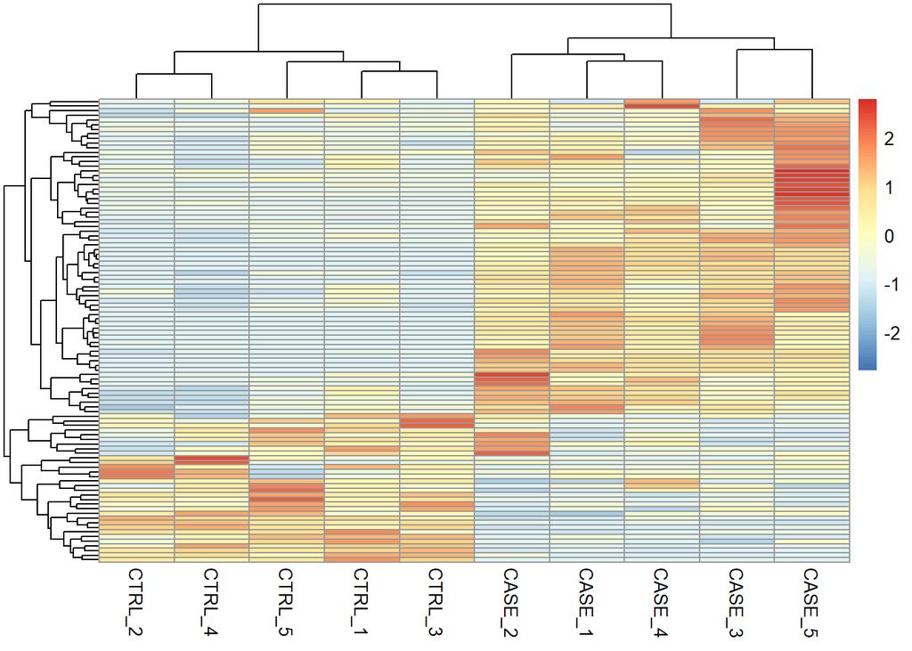

```r
pheatmap(tpm[selectedGenes,], scale = 'row', show_rownames = FALSE)
```

We can also add annotation tracks to the clusters. This is our ‘grouping’ datafile, which contains the grouping of all of the samples. When we inclued this data, we can easily track if our clustering of genes is clustering well or not:

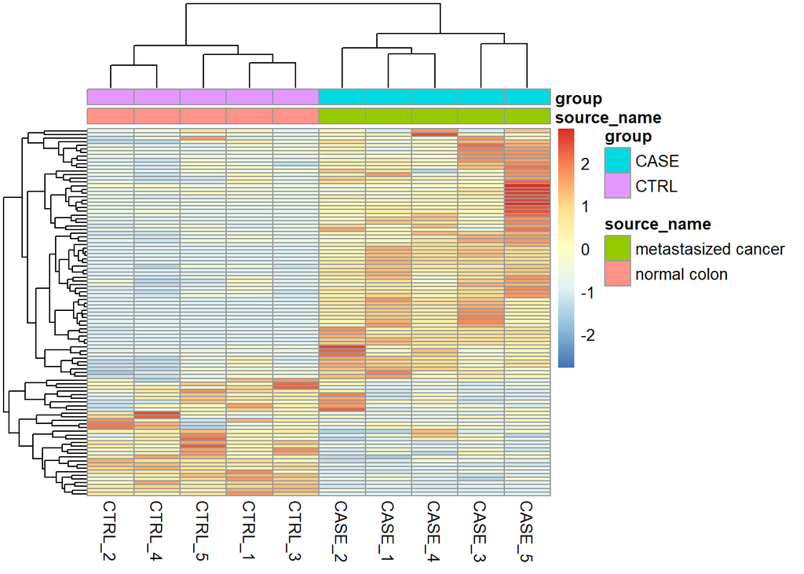

```r
# Import annotation file
colData <- read.table("extracted_data/SRP029880.colData.tsv", header = T, sep = '\t',
                      stringsAsFactors = TRUE)

# Generate annotated Heatmap
{
pheatmap(tpm[selectedGenes,], scale = 'row',
         show_rownames = FALSE,
         annotation_col = colData)
  # Save the plot to your 'figures' directory:
dev.copy(png, file = file.path(getwd(),"figures/GeneClusters_Heatmap.png"))
dev.off()
}
```

```r
## !! NOTE: in R markdown, we must include the figure code within a set of '{}' when using dev.copy/.off commands, in regular R sessions, you may simply just use the dev.copy/.off commands, as long as the figure is in the 'Plots' viewer to the right.
```

## PCA plots

we can use PCA plots to see the clustering of replicates in a 2-D scatter plot

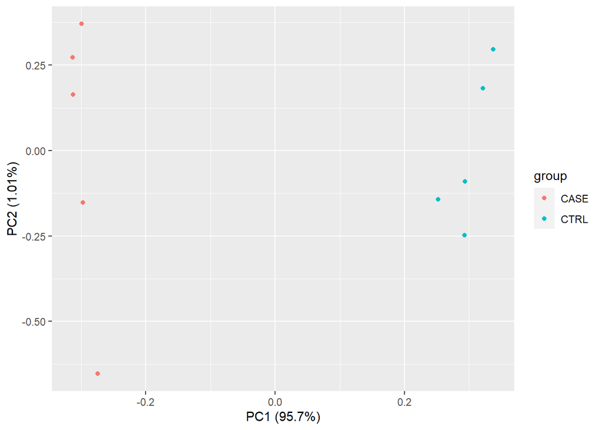

```r
# Transpose the matrix (i.e., swap row and columns, rows => columns, columns => rows)
M <- t(tpm[selectedGenes,])
# transform the counts to log2 scale
M <- log2(M + 1)
# compute PCA
pcaResults <- prcomp(M)
# Plot PCA
autoplot(pcaResults, data = colData, colour = 'group')
```

```r
summary(pcaResults)
```

```
## Importance of components:
##                           PC1     PC2     PC3     PC4     PC5    PC6     PC7
## Standard deviation     24.396 2.50514 2.39327 1.93841 1.79193 1.6357 1.46059
## Proportion of Variance  0.957 0.01009 0.00921 0.00604 0.00516 0.0043 0.00343
## Cumulative Proportion   0.957 0.96706 0.97627 0.98231 0.98747 0.9918 0.99520
##                            PC8     PC9      PC10
## Standard deviation     1.30902 1.12657 4.616e-15
## Proportion of Variance 0.00276 0.00204 0.000e+00
## Cumulative Proportion  0.99796 1.00000 1.000e+00
```

```r
# Export PCA Plot
{
autoplot(pcaResults, data = colData, colour = 'group')
ggsave("figures/PCA_plot.png", width = 8, height = 6)
# Since 'autoplot' is a ggplot2 command, we can use the ggsave function to save the plot
}
```

## Correlation Plots

We can also produce correlation plots to determine the reproducibility of the experiments. Firstly we’ll produce just a simple table of the correlation tests:

```r
correlationMatrix <- cor(tpm)
head(correlationMatrix)
```

```
##           CASE_1    CASE_2    CASE_3    CASE_4    CASE_5    CTRL_1    CTRL_2
## CASE_1 1.0000000 0.9924606 0.9959093 0.9934098 0.9901892 0.9594011 0.9635760
## CASE_2 0.9924606 1.0000000 0.9887290 0.9935931 0.9898379 0.9725646 0.9793835
## CASE_3 0.9959093 0.9887290 1.0000000 0.9950905 0.9928878 0.9648812 0.9617747
## CASE_4 0.9934098 0.9935931 0.9950905 1.0000000 0.9922521 0.9739553 0.9748582
## CASE_5 0.9901892 0.9898379 0.9928878 0.9922521 1.0000000 0.9631663 0.9660868
## CTRL_1 0.9594011 0.9725646 0.9648812 0.9739553 0.9631663 1.0000000 0.9879862
##           CTRL_3    CTRL_4    CTRL_5
## CASE_1 0.9549607 0.9548669 0.9302553
## CASE_2 0.9674813 0.9739136 0.9448425
## CASE_3 0.9555745 0.9551676 0.9401090
## CASE_4 0.9643073 0.9709639 0.9510741
## CASE_5 0.9502160 0.9587173 0.9313136
## CTRL_1 0.9902278 0.9874452 0.9864399
```

Once we have checked out that everything seems to be running OK, we can start to develop more complicated and sophisticated ways to visualize the correlation data:

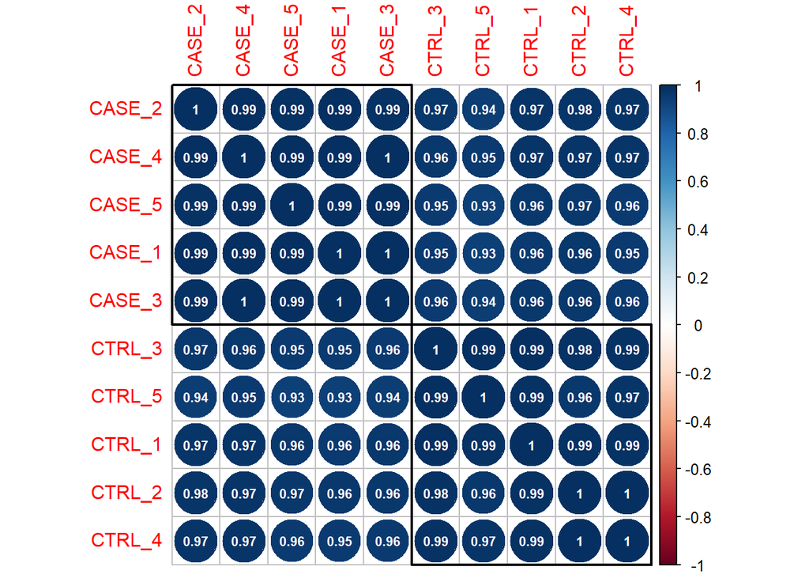

```r
{
corrplot(correlationMatrix, order = 'hclust',
         addrect = 2, addCoef.col = 'white',
         number.cex = 0.7)
  # And save the Plot
dev.copy(png, file = file.path(getwd(),"figures/correlation_plot.png"))
dev.off()
}
```

```r
## Function Explanation:
# 1. The function takes as input a matrix called 'correlationMatrix' that contains the correlation values between different variables.
# 2. It uses the 'hclust' method of ordering the variables in the correlation matrix. 'hclust' stands for hierarchical clustering and it is an # algorithm that groups similar variables together by recursively merging or splitting them.
# 3. 'addrect=2' specifies the number of rectangles to be drawn around the groups of variables, the higher the number the more rectangles will # be drawn
# 4. 'addCoef.col = 'white' specifies that the correlation coefficients should be displayed in white color
# 5. 'number.cex = 0.7' specifies the size of the correlation coefficients to be displayed in the plot
```

The plot above shows the correlation between samples. As we can see, they all have quite highly positively correlated with eachother.

We can take correlation plots one step further by producing a heatmap of the correlation results, including the colData group data as well:

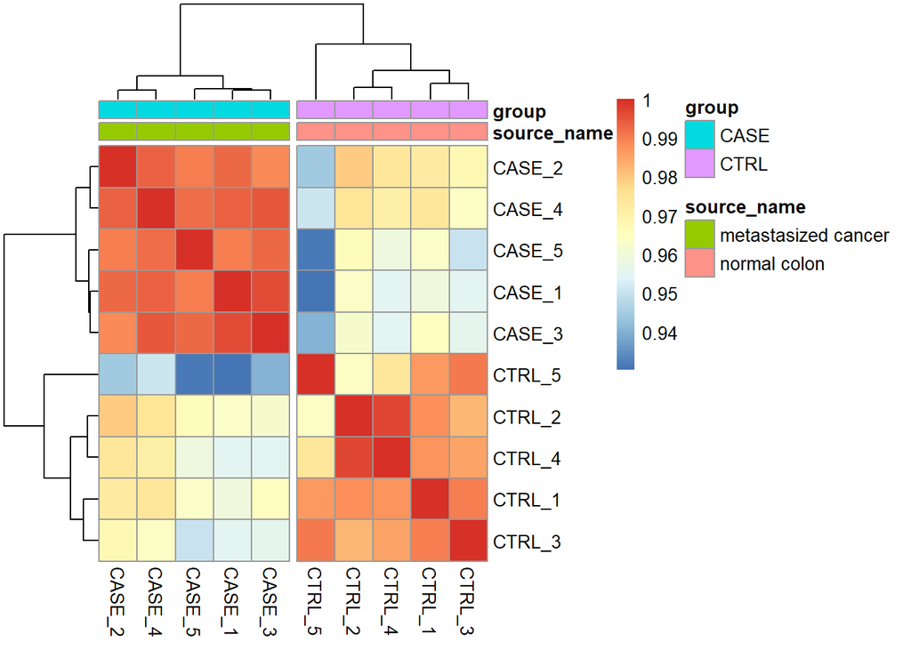

```r
# Transforming the correlation plot into a heatmap figure
# split the clusters into two based on the clustering similarity
{
pheatmap(correlationMatrix,
         annotation_col = colData,
         cutree_cols = 2)
  # And save the figure
  dev.copy(png, file = file.path(getwd(),"figures/corr_heatmap.png"))
  dev.off()
}
```

This plot better emphasises that similar groups are more strongly correlated with eachother than contrasting groups.

# Differential Expression Analysis

Once we are relatively happy with our data, we can begin to perform one of the first downstream analyses: **Differential Expression Analysis**. This analysis can be summarized as calculated the difference in expression level of a given gene between a given contrast (i.e. Control vs. Case). We can examine if the expression of genes is up-/down-regulated, which will be used in subsequent analysis to determine the phenotypic traits of these significantly differentially expressed genes. For Study of diseases, this can inform on what pathways and systems of an organisms may be affected by disease. In my case, differentially expressed genes will give us an insight into how stressors affect the expression levels of genes, which we can use to infer the physiological phenomena occuring in the anemones in relation to the stressors.

```r
# remove the 'width' column
countData <- as.matrix(subset(counts, select = c(-width)))
# define the experimental setup
colData <- read.table("extracted_data/SRP029880.colData.tsv", header = T, sep = '\t',
                      stringsAsFactors = TRUE)

# Specify what we want to include in the design of our DEseq. Group here denotes the column which specifies whether the sample is either the 'CTRL' or 'CASE' class.
designFormula <- "~ group"
```

Now with a objects created, we can build and execute our DEseq analysis:

```r
## Build initial DEseq matrix
dds <- DESeqDataSetFromMatrix(countData = countData,
                              colData = colData,
                              design = as.formula(designFormula))
    # This can take some time to complete

## Remove genes that have almost no information in any give samples
dds <- dds[ rowSums(DESeq2::counts(dds)) > 1, ]

# Now perform Differential expression analysis
dds <- DESeq(dds)
    # This can take some time to complete
```

With out DEA complete, we now want to contrast the different ‘groups’ of samples against eachother to determine the difference in expression levels. Once this is complete, we can now move onto Diagnostics of our DEA.

```r
# Compute the contrast for the 'group' variable where 'CTRL' samples are used as the control group.
DEresults = results(dds, contrast = c("group", 'CASE', 'CTRL'))
# Sort results by increasing p-value
DEresults <- DEresults[order(DEresults$pvalue),]
```

# Diagnostic Plots of DEA

## MA Plot

A scatter plot where the X-axis denotes the average normalized counts across samples and the y-axis denotes the log fold change in the given contrast.

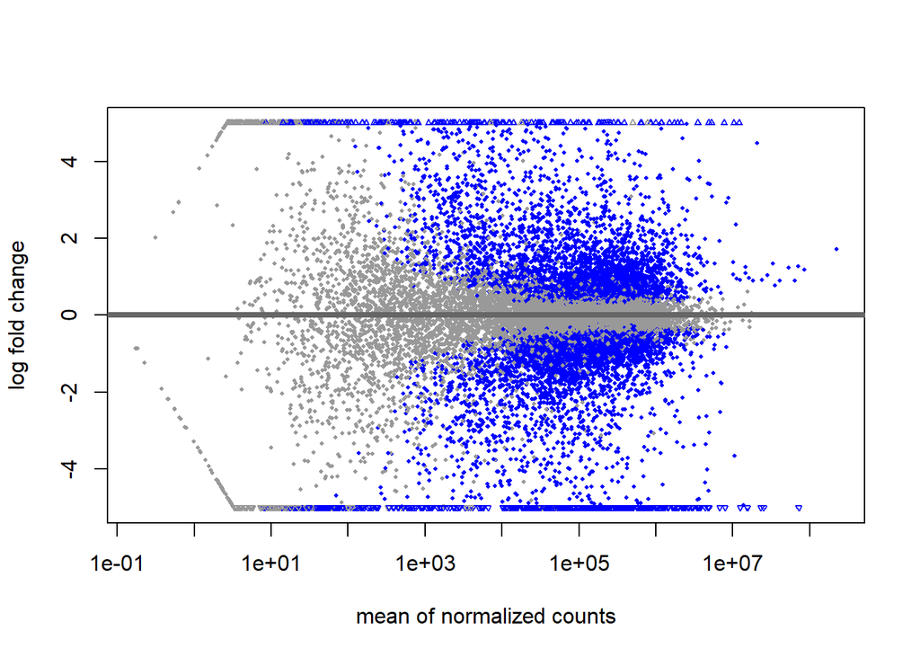

```r
# Most points will be on the horizontal 0 line as most genes are not
# differentially expressed
{
DESeq2::plotMA(object = dds, ylim = c(-5, 5))
  dev.copy(png, file = file.path(getwd(),"figures/MA_plot.png"))
  dev.off()
}
```

## P-value distribution

This shows the distribution of the raw p-values of the DEA. It’s important to look at this because it shows the validity of the adjustments for multiple testing - otherwise your DEA results are meaningless!! We will constrict the plot to only include. We expect to see a peak ~ low p-value and a uniform distribution above 0.1

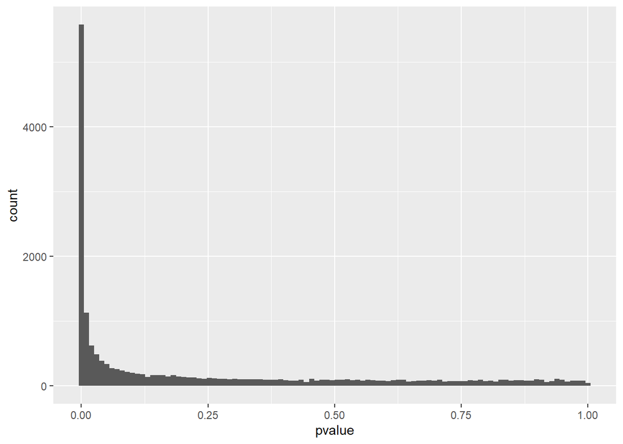

```r
ggplot(data = as.data.frame(DEresults), aes(x = pvalue)) +
    geom_histogram(bins = 100)
```

```r
# Saving Plot
{
  ggplot(data = as.data.frame(DEresults), aes(x = pvalue)) +
    geom_histogram(bins = 100)
  ggsave("figures/P-Value_Distributions.png", width = 8, height = 6)
}
```

## PCA Plot

checks the biological reproducibility of the sample replicates in a PCA plot or a heatmap.to plot PCA results, we need to extract the normalized counts from the DEseqDataSet object. It is possible to colour the points in the scatter plot by the variable of interest, which helps to see if the replicates cluster well.

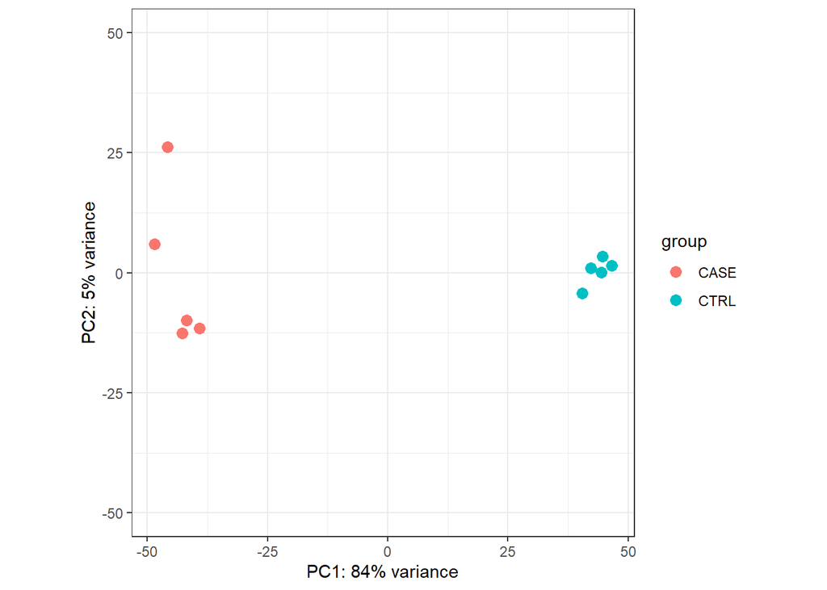

```r
rld <- rlog(dds)

DESeq2::plotPCA(rld, ntop = 500, intgroup = 'group') + ylim(-50, 50) + theme_bw()
```

```r
# And save plot
{
  DESeq2::plotPCA(rld, ntop = 500, intgroup = 'group') +
    ylim(-50, 50) + theme_bw()
  ggsave("figures/DEA_PCA_plot.png", width = 8, height = 6)
}
```

## Relative Log Expression (RLE) plot

useful in finding out if the data at hand needs normalization. Runs a quick diagnostic to be applied on the raw or normalized count matrices to see if further processing is required.

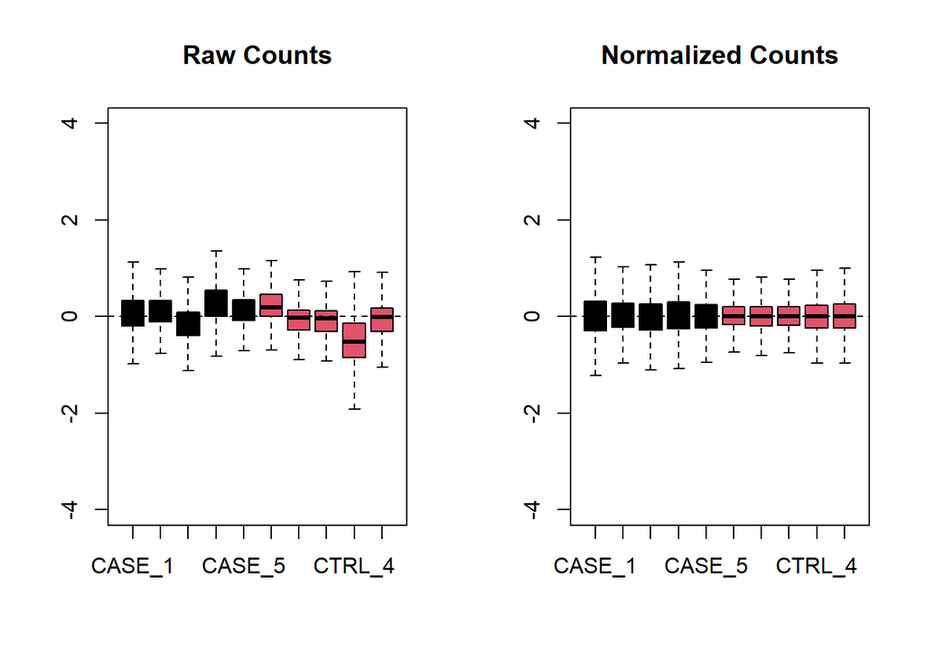

```r
{
  par(mfrow = c(1, 2))
  plotRLE(countData, outline=FALSE, ylim=c(-4, 4),
          col=as.numeric(colData$group),
          main = 'Raw Counts')
  plotRLE(DESeq2::counts(dds, normalized = TRUE),
          outline=FALSE, ylim=c(-4, 4),
          col = as.numeric(colData$group),
          main = 'Normalized Counts')
  par(mfrow = c(1, 1))
dev.copy(png, file = file.path(getwd(),"figures/RLE_plot.png"))
dev.off()
}
```

Here the RLE plot is comprised of boxplots, where each box-plot = distribution of the relative log expression of the genes expressed in the corresponding sample Each genes expression is divided by the median expression value of that gene across all sample Ideally the boxplots are centered around the horizontal zero line and are as tightly distributed as possible (Risso, Ngai, Speed, et al. 2014) We can observe here how the noramlized dataset has mproved upon the raw count data for all the samples However, in some cases, it is important to visualise the RLE plots in combination with other diagnostic plots such as PCA plots, heatmaps, and correlation plots to see if there is more unwanted variation in the data, which can be further accounted for using packages such as RUVseq and sva.

# Functional Enrichment Analysis

## GO (Gene Ontology) Term Analysis

A commonly used tool to group genes by related functions is to do enrichment analysis. This groups genes into sets by shared functional terms. To make sure descriptions of functions are the same, initiatives such as Gene Ontology Consortium have collate a list of Gene Ontology (GO) terms for each gene Probably the most common analysis applied after a differential expression analysis. GO term analysis helps to quickly find out systematic changes that can describe differences between groups of sample Select genes that are significantly differentially expressed between case and control samples. We will select genes with adjusted p-values < 0.1 and that show a -ve/+ve 2-fold change in case vs. control.

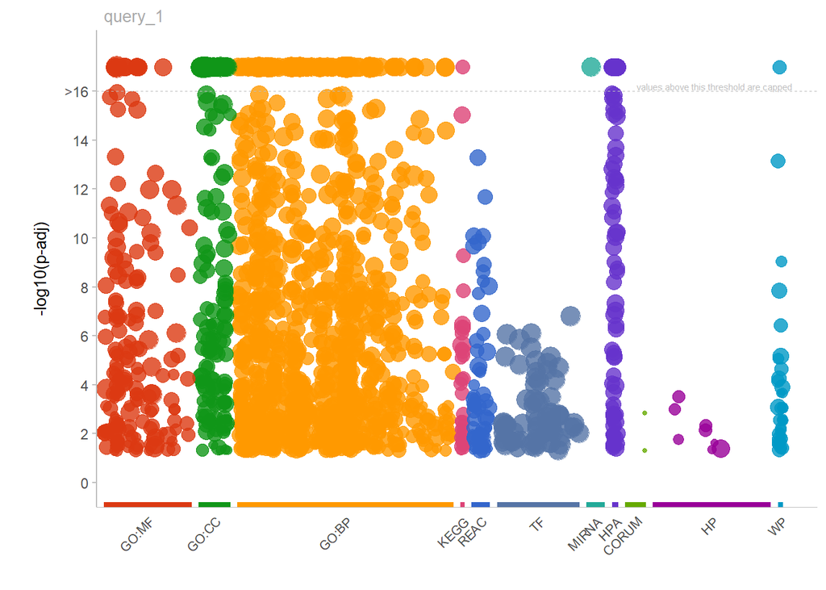

```r
# extract differential expression results
DEresults <- results(dds, contrast = c('group', 'CASE', 'CTRL'))

#remove genes with NA values
DE <- DEresults[!is.na(DEresults$padj),]
#select genes with adjusted p-values below 0.1
DE <- DE[DE$padj < 0.1,]
#select genes with absolute log2 fold change above 1 (two-fold change)
DE <- DE[abs(DE$log2FoldChange) > 1,]

#get the list of genes of interest
genesOfInterest <- rownames(DE)

#calculate enriched GO terms
goResults <- gprofiler(query = genesOfInterest,
                       organism = 'hsapiens',
                       src_filter = 'GO',
                       hier_filtering = 'moderate')

## gprofiler2 Package - not included in guide:
#calculate enriched GO terms
goResults2 <- gost(query = genesOfInterest,
                 organism = "hsapiens", ordered_query = FALSE,
                 multi_query = FALSE, significant = TRUE, exclude_iea = FALSE,
                 measure_underrepresentation = FALSE, evcodes = FALSE,
                 user_threshold = 0.05, correction_method = "g_SCS",
                 domain_scope = "annotated", custom_bg = NULL,
                 numeric_ns = "", sources = NULL)

gostres_link <- gost(query = genesOfInterest,
                     as_short_link = TRUE)
# https://biit.cs.ut.ee/gplink/l/E7naeUS5Su

gostplot(goResults2,
         capped = TRUE,
         interactive = FALSE) # Change this to 'TRUE' for plot interactions
```

```r
# And save plot
{
gostplot(goResults2,
         capped = TRUE,
         interactive = FALSE) # Change this to 'TRUE' for plot interactions
  ggsave("figures/GO_Term_Analysis.png", width = 8, height = 6)
}
```

## Gene Set Enrichment Analysis

valuable exploratory analysis tool that can associate systematic changes to a high-level function rather than individual genes.

Let’s define the first gene set as the list of genes from one of the significant GO terms found in the GO analysis. order go results by pvalue:

```r
goResults <- goResults[order(goResults$p.value),]

# restrict the terms that have at most 100 genes overlapping with the query
go <- goResults[goResults$overlap.size < 100,]

# use the top term from this table to create a gene set
geneSet1 <- unlist(strsplit(go[1,]$intersection, ','))

## Function Explanation
# 1. It creates a new variable called 'geneSet1' which is the result of the following operations.
# 2. It selects the first element of the second column of a dataframe/matrix called 'go' using indexing # [1,]
# 3. It accesses the 'intersection' element of the selected element using $intersection
# 4. It splits the 'intersection' element by ',' using the strsplit() function.
# 5. It converts the resulting list into a vector using unlist()
```

Define another gene set by just randomly selecting 25 genes from the counts table get normalized counts from DESeq2 results:

```r
normalizedCounts <- DESeq2::counts(dds, normalized = TRUE)
geneSet2 <- sample(rownames(normalizedCounts), 25)

geneSets <- list('top_GO_term' = geneSet1,
                 'random_set' = geneSet2)
```

Using the defined gene sets, we’d like to do a group comparison between the case samples with respect to the control samples

```r
# use the normalized counts to carry out a GSEA.
gseaResults <- gage(exprs = log2(normalizedCounts+1),
                    ref = match(rownames(colData[colData$group == 'CTRL',]),
                                colnames(normalizedCounts)),
                    samp = match(rownames(colData[colData$group == 'CASE',]),
                                 colnames(normalizedCounts)),
                    gsets = geneSets, compare = 'as.group')

## Function Explanation:
# 1. It creates a new variable called 'gseaResults' which is the result of the following operations.
# 2. It performs GSEA on the 'log2(normalizedCounts+1)' dataframe, which is the log2 transformed and # normalized count data with a pseudocount of 1 added.
# 3. It uses 'ref' parameter to specify the control group samples in the 'colData' dataframe by matching # the sample names with the column names of the normalized count dataframe 'normalizedCounts' using # the match() function.
# 4. It uses 'samp' parameter to specify the case group samples in the 'colData' dataframe by matching # the sample names with the column names of the normalized count dataframe 'normalizedCounts' using # the match() function.
# 5. It uses 'gsets' parameter to specify the gene sets to be tested for enrichment using the 'geneSets' # dataframe.
# 6. It uses 'compare' parameter to specify that the analysis should be performed as a group comparison # between the control and case groups using 'as.group'
```

We can see if there is significant up-regulation or down-regulation of the gene set in the case group by accessing “gseaResults$greater" or "gseaResults$less”:

```r
gseaResults$greater
```

```
##                p.geomean stat.mean        p.val        q.val set.size
## top_GO_term 2.613981e-09  7.199400 2.613981e-09 5.227961e-09       32
## random_set  8.441027e-01 -1.024612 8.441027e-01 8.441027e-01       25
##                     exp1
## top_GO_term 2.613981e-09
## random_set  8.441027e-01
```

```r
gseaResults$less
```

```
##             p.geomean stat.mean     p.val     q.val set.size      exp1
## random_set  0.1558973 -1.024612 0.1558973 0.3117947       25 0.1558973
## top_GO_term 1.0000000  7.199400 1.0000000 1.0000000       32 1.0000000
```

The random gene set shows no significant changes in regulation, but the top GO term shows a significant up-regulation. Lets use a heatmap to see this:

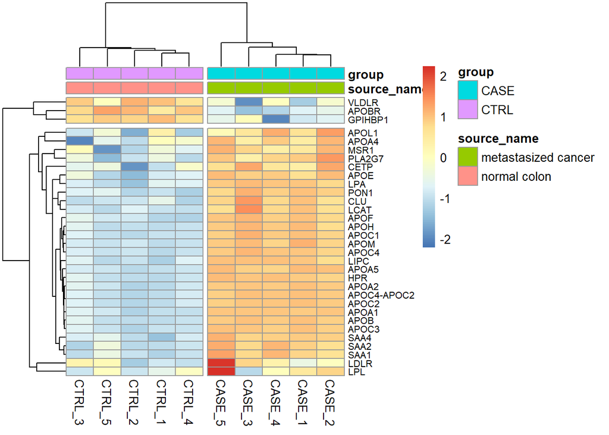

```r
# get the expression data for the gene set of interest
M <- normalizedCounts[rownames(normalizedCounts) %in% geneSet1, ]
# log transform the counts for visualization scaling by row helps visualizing
# relative change of expression of a gene in multiple conditions
{
pheatmap(log2(M+1),
         annotation_col = colData,
         show_rownames = TRUE,
         fontsize_row = 8,
         scale = 'row',
         cutree_cols = 2,
         cutree_rows = 2)
dev.copy(png, file = file.path(getwd(),"figures/GSEA_Heatmap.png"))
dev.off()
}
```

# Accounting for Additional Sources of Variation (Known)

Sometimes unforeseen variables may contribute to some of the variation in our results (e.g. batch number, temperature of sample storage, etc.. First we use DESeq2 to account for possible sources of variation when they are known.

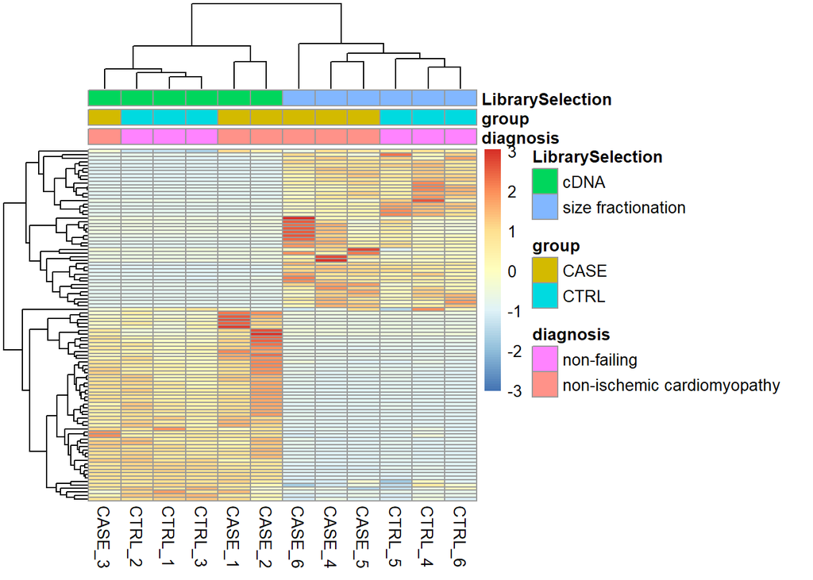

```r
#!! Using a different dataset for this!!
counts <- read.table("extracted_data/SRP021193.raw_counts.tsv")
colData <- read.table("extracted_data/SRP021193.colData.tsv",
                      header = T, sep = '\t',
                      stringsAsFactors = TRUE)

## Look at how samples are clustered by calculating TPM as a heatmap:

#find gene length normalized values
geneLengths <- counts$width

# Calculate RPK calue
rpk <- apply( subset(counts, select = c(-width)), 2,
              function(x) x/(geneLengths/1000))

# normalize by the sample size using rpk values (TPM)
tpm <- apply(rpk, 2, function(x) x / sum(as.numeric(x)) * 10^6)

# Subset top 100 most variable genes in data:
selectedGenes <- names(sort(apply(tpm, 1, var),
                            decreasing = T)[1:100])

## Heatmap plot for covariates
{
pheatmap(tpm[selectedGenes,],
         scale = 'row',
         annotation_col = colData,
         show_rownames = FALSE)
dev.copy(png, file = file.path(getwd(),"figures/Covariate_heatmap.png"))
dev.off()
} # Save Image
```

We can see that library section variable is the dominating variable, rather than the ‘diagnostic variable’. So how do we account for this covariate?

```r
# Now we instruct DESeq2 to account for the library selection variable:
# remove the 'width' column from the counts matrix
countData <- as.matrix(subset(counts, select = c(-width)))

# set up a DESeqDataSet object, including the 'LibrarySelection' covariate in the design matrix
dds <- DESeqDataSetFromMatrix(countData = countData,
                              colData = colData,
                              design = ~ LibrarySelection + group)

# Run the DE
dds <- DESeq(dds)
# extract results
DEresults <- results(dds, contrast = c('group', 'CASE', 'CTRL'))
```

When we construct the design formula, it is very important to keep in mind the order that the variables are included. We leave the variable of interest ‘group’ to last, adding in as many covariates as we want to the beginning of the design formula.

# Accounting for Unknown Covariates with RUVseq

Use tools such as RUVseq or sva to estimate potential sources of variation and clean up the counts table from those sources of variation. Later on, the estimate covariates can be integrated into DESeq2’s design formul Use RUVseq first to diagnose the problem and solve it.

*Loading a new dataset for this example*

```r
ounts_file <- system.file('extdata/rna-seq/SRP049988.raw_counts.tsv',
                           package = 'compGenomRData')
colData_file <- system.file('extdata/rna-seq/SRP049988.colData.tsv',
                            package = 'compGenomRData')

counts <- read.table("extracted_data/SRP049988.raw_counts.tsv")
colData <- read.table("extracted_data/SRP049988.colData.tsv", header = T,
                      sep = '\t', stringsAsFactors = TRUE)

# Simplify condition descriptions
colData$source_name <- ifelse(colData$group == 'CASE',
                              'EHF_overexpression', 'Empty_Vector')

# Calculate Gene parameters
geneLengths <- counts$width
rpk <- apply( subset(counts, select = c(-width)), 2,
              function(x) x/(geneLengths/1000))
tpm <- apply(rpk, 2, function(x) x / sum(as.numeric(x)) * 10^6)
selectedGenes <- names(sort(apply(tpm, 1, var),
                            decreasing = T)[1:100])
```

With the data imported, we can explore what the problem looks like:

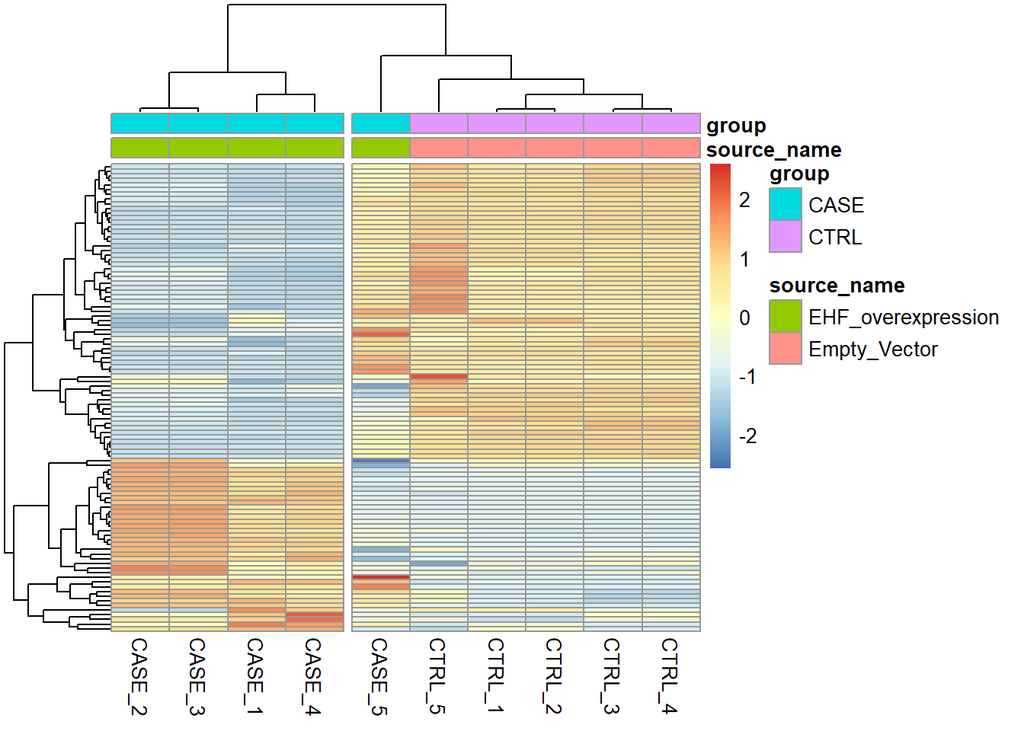

```r
{
pheatmap(tpm[selectedGenes,],
         scale = 'row',
         annotation_col = colData,
         cutree_cols = 2,
         show_rownames = FALSE)
dev.copy(png, file = file.path(getwd(),"figures/Unknown_Covariate_heatmap.png"))
dev.off()
}
```

CASE_5 clusters more closely to the control samples. Could be the result of some batch effect, or any other technical preparation steps. However, the colData object doesnt contain any variables that we can use to pinpoint the exact cause of this. So we’ll use RUVseq to estimate potential covariates to see if the clustering results can be improved:

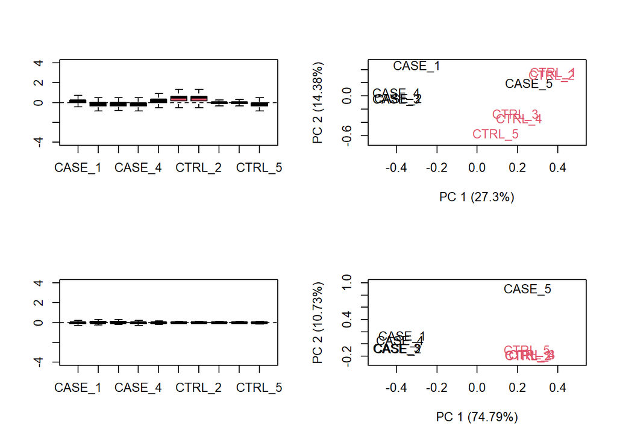

```r
# remove 'width' column from counts
countData <- as.matrix(subset(counts, select = c(-width)))
# create a seqExpressionSet object using EDASeq package
set <- newSeqExpressionSet(counts = countData,
                           phenoData = colData)

{
par(mfrow = c(2,2))
  # Make an RLE plot and a PCA plot on raw count data and color samples by group
plotRLE(set, outline=FALSE, ylim=c(-4, 4), col=as.numeric(colData$group))
plotPCA(set, col = as.numeric(colData$group), adj = 0.5,
        ylim = c(-0.7, 0.5), xlim = c(-0.5, 0.5))

  # make RLE and PCA plots on TPM matrix
plotRLE(tpm, outline=FALSE, ylim=c(-4, 4), col=as.numeric(colData$group))
plotPCA(tpm, col=as.numeric(colData$group), adj = 0.5,
        ylim = c(-0.3, 1), xlim = c(-0.5, 0.5))

dev.copy(png, file = file.path(getwd(),"figures/RLE-PCA_Raw-VS-TPM.png"))
dev.off()

par(mfrow = c(1,1))
}
```

Both RLE and PCA plots look better on normalized data, but still suggests the necessity to further improvement, since case_5 sample still clusters with the control samples. We haven’t yet accounted for the source of the variation.

## Removal of the unwanted variation from the data

### Using RUVg

Using HKGs as negative controls and as a refernces to correct systematic biases in the data, we should be able to remove unwanted variation. Let’s use a list of ~500 house-keeping genes compiled here: https://www.tau.ac.il/~elieis/HKG/HK_genes.txt.

```r
HK_genes <- read.table("extracted_data/HK_genes.txt")

# let's take an intersection of the house-keeping genes with the genes available
# in the count table
house_keeping_genes <- intersect(rownames(set), HK_genes$V1)
```

Now will run RUVg() with different number of factors of unwanted variation. Plot the PCA after removing the unwante variation, we should see which k values, numbe of factors, produce better seperation between sample groups. now, we use these genes as the empirical set of genes as input to RUVg. we try different values of k and see how the PCA plots look:

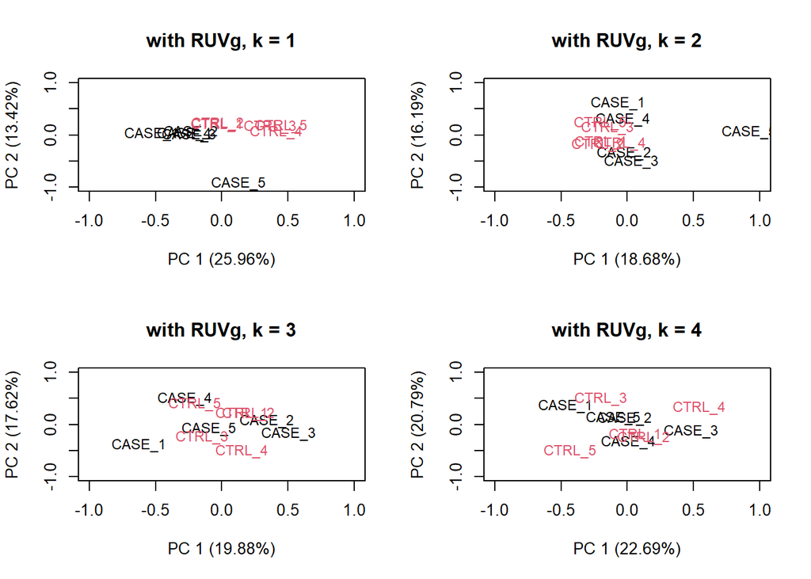

```r
{
par(mfrow = c(2, 2))
for(k in 1:4) {
  set_g <- RUVg(x = set, cIdx = house_keeping_genes, k = k)
  plotPCA(set_g, col=as.numeric(colData$group), cex = 0.9, adj = 0.5,
          main = paste0('with RUVg, k = ',k),
          ylim = c(-1, 1), xlim = c(-1, 1), )
}
  ggsave("figures/RUVg_plot.png", width = 8, height = 6)
}
```

We can see that k = 1 is enough to separate the case vs. control. So now we re-run the RUVg() function with the HKGs to do more diagnostic plots:

```r
# choose k = 1
set_g <- RUVg(x = set, cIdx = house_keeping_genes, k = 1)
```

### Diagnostic Plots

#### RLE Plots

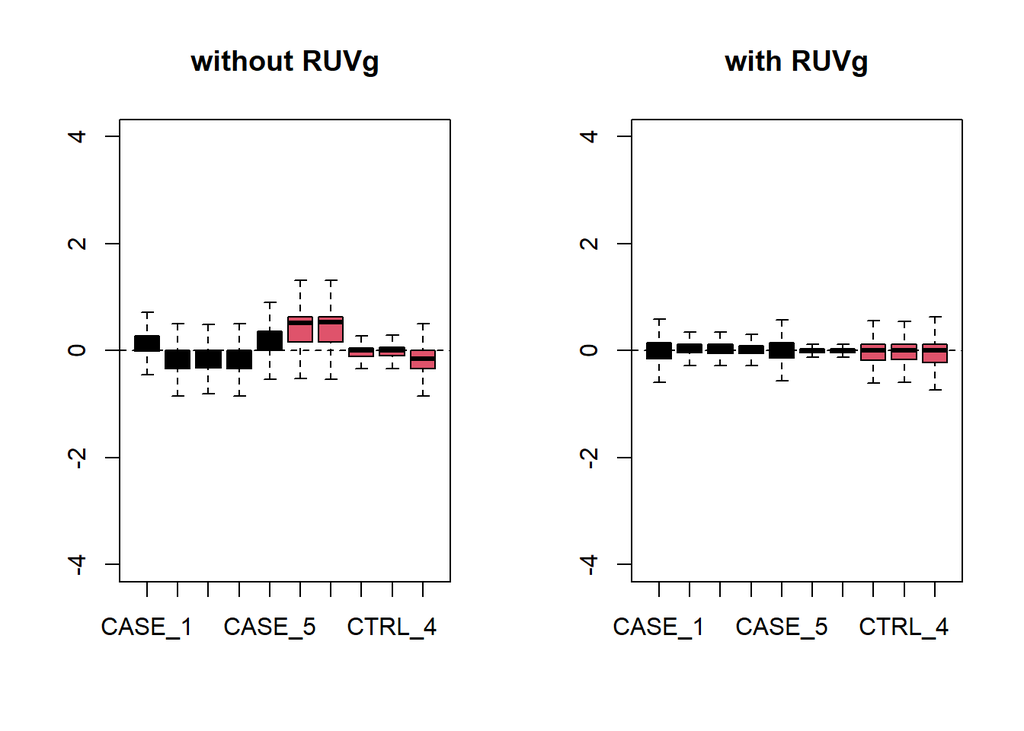

```r
{
par(mfrow = c(1,2))
plotRLE(set, outline=FALSE, ylim=c(-4, 4),
        col=as.numeric(colData$group), main = 'without RUVg')
plotRLE(set_g, outline=FALSE, ylim=c(-4, 4),
        col=as.numeric(colData$group), main = 'with RUVg')
dev.copy(png, file = file.path(getwd(),"figures/RLE_Adjusted.png"))
dev.off()
par(mfrow = c(1,1))
}
```

#### PCA plots

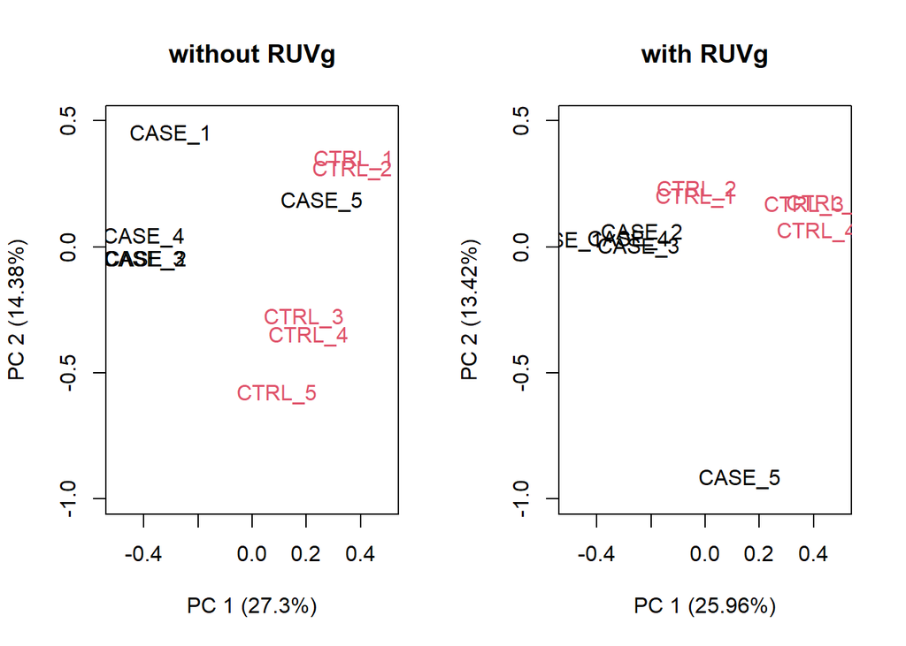

```r
{
par(mfrow = c(1,2))
plotPCA(set, col=as.numeric(colData$group), adj = 0.5,
        main = 'without RUVg',
        ylim = c(-1, 0.5), xlim = c(-0.5, 0.5))
plotPCA(set_g, col=as.numeric(colData$group), adj = 0.5,
        main = 'with RUVg',
        ylim = c(-1, 0.5), xlim = c(-0.5, 0.5))
  ggsave("figures/PCA_adjusted.png", width = 8, height = 6)
par(mfrow = c(1,1))
}
```

```r
summary(pcaResults)
```

```
## Importance of components:
##                           PC1     PC2     PC3     PC4     PC5    PC6     PC7
## Standard deviation     24.396 2.50514 2.39327 1.93841 1.79193 1.6357 1.46059
## Proportion of Variance  0.957 0.01009 0.00921 0.00604 0.00516 0.0043 0.00343
## Cumulative Proportion   0.957 0.96706 0.97627 0.98231 0.98747 0.9918 0.99520
##                            PC8     PC9      PC10
## Standard deviation     1.30902 1.12657 4.616e-15
## Proportion of Variance 0.00276 0.00204 0.000e+00
## Cumulative Proportion  0.99796 1.00000 1.000e+00
```

#### Correlation Plots

```r
correlationMatrix <- cor(tpm)
correlationMatrix
```

```
##           CASE_1    CASE_2    CASE_3    CASE_4    CASE_5    CTRL_1    CTRL_2
## CASE_1 1.0000000 0.9961690 0.9959305 0.9986144 0.9945803 0.9911570 0.9911952
## CASE_2 0.9961690 1.0000000 0.9999854 0.9968327 0.9916057 0.9883575 0.9884518
## CASE_3 0.9959305 0.9999854 1.0000000 0.9966242 0.9913651 0.9879856 0.9880902
## CASE_4 0.9986144 0.9968327 0.9966242 1.0000000 0.9908484 0.9860726 0.9860685
## CASE_5 0.9945803 0.9916057 0.9913651 0.9908484 1.0000000 0.9962629 0.9961979
## CTRL_1 0.9911570 0.9883575 0.9879856 0.9860726 0.9962629 1.0000000 0.9999936
## CTRL_2 0.9911952 0.9884518 0.9880902 0.9860685 0.9961979 0.9999936 1.0000000
## CTRL_3 0.9931104 0.9916989 0.9913074 0.9904624 0.9962390 0.9986002 0.9985544
## CTRL_4 0.9930157 0.9918452 0.9914602 0.9904938 0.9960927 0.9984587 0.9984162
## CTRL_5 0.9887702 0.9841944 0.9837604 0.9839601 0.9954525 0.9980213 0.9978734
##           CTRL_3    CTRL_4    CTRL_5
## CASE_1 0.9931104 0.9930157 0.9887702
## CASE_2 0.9916989 0.9918452 0.9841944
## CASE_3 0.9913074 0.9914602 0.9837604
## CASE_4 0.9904624 0.9904938 0.9839601
## CASE_5 0.9962390 0.9960927 0.9954525
## CTRL_1 0.9986002 0.9984587 0.9980213
## CTRL_2 0.9985544 0.9984162 0.9978734
## CTRL_3 1.0000000 0.9999893 0.9964841
## CTRL_4 0.9999893 1.0000000 0.9962344
## CTRL_5 0.9964841 0.9962344 1.0000000
```